# A03_G28512359

JINGSI WU

9/16/2018

To start solving the questions, we need to load the dataset and do some data prepocessing.

First we read our dataset.

```r
mydf <- read.csv("kicksfootball.csv")
summary(mydf)
```

```
##      yards      goal    practiceormatch
##  Min.   :18.0   N:193   M: 86
##  1st Qu.:28.0   Y:742   P:866
##  Median :37.0   y: 17
##  Mean   :36.5
##  3rd Qu.:45.0
##  Max.   :62.0
```

As we can see in the summary, there are upper and lower “y” in the dataset, both “y” represent Melvin has reached his goal. So when we change catagorical data to dummy variables, “y” also need to be difined.

```r
mydf$prac_mat_bin <- ifelse(mydf$practiceormatch == "P", 1, 0)
mydf$gbin <- ifelse(mydf$goal == "Y"|mydf$goal == "y", 1, 0)
```

Data preprocessing has done! Now let’s start solving the problems.

## Part A

First we need to check some key information of the dataset.

```r
str(mydf)
```

```
## 'data.frame':    952 obs. of  5 variables:
##  $ yards          : int  18 19 19 19 19 19 20 20 20 20 ...
##  $ goal           : Factor w/ 3 levels "N","Y","y": 2 2 2 2 2 2 1 2 2 2 ...
##  $ practiceormatch: Factor w/ 2 levels "M","P": 2 2 2 2 2 2 2 1 2 2 ...
##  $ prac_mat_bin   : num  1 1 1 1 1 1 1 0 1 1 ...
##  $ gbin           : num  1 1 1 1 1 1 0 1 1 1 ...
```

As you can see, there are 952 observations in the dataset. Now let’s count how many times did Melvin succeed.

```r
summary(mydf)
```

```
##      yards      goal    practiceormatch  prac_mat_bin         gbin
##  Min.   :18.0   N:193   M: 86           Min.   :0.0000   Min.   :0.0000
##  1st Qu.:28.0   Y:742   P:866           1st Qu.:1.0000   1st Qu.:1.0000
##  Median :37.0   y: 17                   Median :1.0000   Median :1.0000
##  Mean   :36.5                           Mean   :0.9097   Mean   :0.7973
##  3rd Qu.:45.0                           3rd Qu.:1.0000   3rd Qu.:1.0000
##  Max.   :62.0                           Max.   :1.0000   Max.   :1.0000
```

The probability that Melvin is going to reach his goal is

```r
goalreach <- (742+17)/952
print(goalreach)
```

```
## [1] 0.7972689
```

## Part B

To build the practice and match model, we need to seperate the data first.

```r
gbin_prac <- subset(mydf, mydf$prac_mat_bin == 1)
gbin_mat <- subset(mydf, mydf$prac_mat_bin == 0)
```

Then we can fit the data into the logistic regression model and see the result.

```r
goal_prac.mod <- glm(gbin ~ yards,
               data = gbin_prac,
               family = binomial)

goal_mat.mod <- glm(gbin ~ yards,
                     data = gbin_mat,
                     family = binomial)
summary(goal_prac.mod)
```

```
##
## Call:
## glm(formula = gbin ~ yards, family = binomial, data = gbin_prac)
##
## Deviance Residuals:
##     Min       1Q   Median       3Q      Max
## -2.6313   0.2803   0.4236   0.6937   1.4465
##
## Coefficients:
##             Estimate Std. Error z value Pr(>|z|)
## (Intercept)  5.55809    0.46557   11.94   <2e-16 ***
## yards       -0.10640    0.01097   -9.70   <2e-16 ***
## ---
## Signif. codes:  0 '***' 0.001 '**' 0.01 '*' 0.05 '.' 0.1 ' ' 1
##
## (Dispersion parameter for binomial family taken to be 1)
##
##     Null deviance: 866.14  on 865  degrees of freedom
## Residual deviance: 747.26  on 864  degrees of freedom
## AIC: 751.26
##
## Number of Fisher Scoring iterations: 5
```

```r
summary(goal_mat.mod)
```

```
##
## Call:
## glm(formula = gbin ~ yards, family = binomial, data = gbin_mat)
##
## Deviance Residuals:
##     Min       1Q   Median       3Q      Max
## -2.3165   0.1751   0.3636   0.6814   1.4963
##
## Coefficients:
##             Estimate Std. Error z value Pr(>|z|)
## (Intercept)  7.10921    1.70595   4.167 3.08e-05 ***
## yards       -0.14507    0.03899  -3.720 0.000199 ***
## ---
## Signif. codes:  0 '***' 0.001 '**' 0.01 '*' 0.05 '.' 0.1 ' ' 1
##
## (Dispersion parameter for binomial family taken to be 1)
##
##     Null deviance: 93.284  on 85  degrees of freedom
## Residual deviance: 73.414  on 84  degrees of freedom
## AIC: 77.414
##
## Number of Fisher Scoring iterations: 5
```

The regression model seems no problem, so now we can strat to predict Melvin’s performance.

```r
pred <- c(20, 40, 60)
newdata  = data.frame(yards = pred)
predict(goal_prac.mod, newdata, type = "response")
```

```
##         1         2         3
## 0.9686287 0.7861530 0.3044478
```

```r
predict(goal_mat.mod, newdata, type = "response")
```

```
##         1         2         3
## 0.9853407 0.7869448 0.1687243
```

## Part C

Before we start to plot, we need to reorganize the data and create a new dataset. I’m going to predict the performance of Melvin from 15 yards to 75 yards. Also, for each value we must create a corresponding lable.

```r
yard_plot <- data.frame(seq(15,75,1))
colnames(yard_plot) <- "yards"
prac_label <- data.frame(rep("Practice", 61))
prac_plot <- data.frame(yard_plot, predict(goal_prac.mod, yard_plot, type = "response"), prac_label)
mat_label <- data.frame(rep("Match", 61))
mat_plot <- data.frame(yard_plot, predict(goal_mat.mod, yard_plot, type = "response"), mat_label)
```

Then we give the dataset above same column names so that we can combine them together

```r
colnames(mat_plot) <- c("yards", "probability", "labels")
colnames(prac_plot) <- c("yards", "probability", "labels")
plotset <- rbind(prac_plot, mat_plot)
```

Finally, use ggplot2 to get the picture

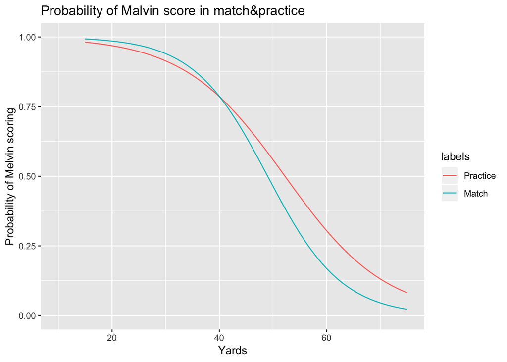

```r
ggplot(plotset,aes(x = yards, y = probability, col = labels ))+
  geom_line()+
  xlim(c(10,75))+
  ylim(c(0,1))+
  labs(x='Yards',y='Probability of Melvin scoring', title = "Probability of Malvin score in match&practice" )
```